# Risk Factor Analysis

## Outcome Variable

**Outcome Variable:** ever_stunted

## Predictor Variables

**Intervention Variable:** hhwealth_quart

**Adjustment Set:**

unadjusted

## Stratifying Variables

The analysis was stratified on these variable(s):

- agecat
- studyid
- country

## Data Summary

| agecat | studyid | country | hhwealth_quart | ever_stunted | n_cell | n |
| --- | --- | --- | --- | --- | --- | --- |
| 0-24 months | CMC-V-BCS-2002 | INDIA | Wealth Q4 | 0 | 6 | 373 |
| 0-24 months | CMC-V-BCS-2002 | INDIA | Wealth Q4 | 1 | 90 | 373 |
| 0-24 months | CMC-V-BCS-2002 | INDIA | Wealth Q1 | 0 | 6 | 373 |
| 0-24 months | CMC-V-BCS-2002 | INDIA | Wealth Q1 | 1 | 85 | 373 |
| 0-24 months | CMC-V-BCS-2002 | INDIA | Wealth Q2 | 0 | 8 | 373 |
| 0-24 months | CMC-V-BCS-2002 | INDIA | Wealth Q2 | 1 | 87 | 373 |
| 0-24 months | CMC-V-BCS-2002 | INDIA | Wealth Q3 | 0 | 8 | 373 |
| 0-24 months | CMC-V-BCS-2002 | INDIA | Wealth Q3 | 1 | 83 | 373 |
| 0-24 months | COHORTS | GUATEMALA | Wealth Q4 | 0 | 130 | 1278 |
| 0-24 months | COHORTS | GUATEMALA | Wealth Q4 | 1 | 355 | 1278 |
| 0-24 months | COHORTS | GUATEMALA | Wealth Q1 | 0 | 47 | 1278 |
| 0-24 months | COHORTS | GUATEMALA | Wealth Q1 | 1 | 198 | 1278 |
| 0-24 months | COHORTS | GUATEMALA | Wealth Q2 | 0 | 45 | 1278 |
| 0-24 months | COHORTS | GUATEMALA | Wealth Q2 | 1 | 215 | 1278 |
| 0-24 months | COHORTS | GUATEMALA | Wealth Q3 | 0 | 70 | 1278 |
| 0-24 months | COHORTS | GUATEMALA | Wealth Q3 | 1 | 218 | 1278 |
| 0-24 months | COHORTS | PHILIPPINES | Wealth Q4 | 0 | 370 | 3057 |
| 0-24 months | COHORTS | PHILIPPINES | Wealth Q4 | 1 | 473 | 3057 |
| 0-24 months | COHORTS | PHILIPPINES | Wealth Q1 | 0 | 195 | 3057 |
| 0-24 months | COHORTS | PHILIPPINES | Wealth Q1 | 1 | 492 | 3057 |
| 0-24 months | COHORTS | PHILIPPINES | Wealth Q2 | 0 | 157 | 3057 |
| 0-24 months | COHORTS | PHILIPPINES | Wealth Q2 | 1 | 385 | 3057 |
| 0-24 months | COHORTS | PHILIPPINES | Wealth Q3 | 0 | 236 | 3057 |
| 0-24 months | COHORTS | PHILIPPINES | Wealth Q3 | 1 | 749 | 3057 |
| 0-24 months | CONTENT | PERU | Wealth Q4 | 0 | 44 | 215 |
| 0-24 months | CONTENT | PERU | Wealth Q4 | 1 | 8 | 215 |
| 0-24 months | CONTENT | PERU | Wealth Q1 | 0 | 42 | 215 |
| 0-24 months | CONTENT | PERU | Wealth Q1 | 1 | 17 | 215 |
| 0-24 months | CONTENT | PERU | Wealth Q2 | 0 | 35 | 215 |
| 0-24 months | CONTENT | PERU | Wealth Q2 | 1 | 17 | 215 |

[output cut: 402 more lines]

The following strata were considered:

- agecat: 0-24 months, studyid: CMC-V-BCS-2002, country: INDIA
- agecat: 0-24 months, studyid: COHORTS, country: GUATEMALA
- agecat: 0-24 months, studyid: COHORTS, country: PHILIPPINES
- agecat: 0-24 months, studyid: CONTENT, country: PERU
- agecat: 0-24 months, studyid: GMS-Nepal, country: NEPAL
- agecat: 0-24 months, studyid: IRC, country: INDIA
- agecat: 0-24 months, studyid: JiVitA-3, country: BANGLADESH
- agecat: 0-24 months, studyid: JiVitA-4, country: BANGLADESH
- agecat: 0-24 months, studyid: LCNI-5, country: MALAWI
- agecat: 0-24 months, studyid: MAL-ED, country: BANGLADESH
- agecat: 0-24 months, studyid: MAL-ED, country: BRAZIL
- agecat: 0-24 months, studyid: MAL-ED, country: INDIA
- agecat: 0-24 months, studyid: MAL-ED, country: NEPAL
- agecat: 0-24 months, studyid: MAL-ED, country: PERU
- agecat: 0-24 months, studyid: MAL-ED, country: SOUTH AFRICA
- agecat: 0-24 months, studyid: MAL-ED, country: TANZANIA, UNITED REPUBLIC OF
- agecat: 0-24 months, studyid: PROVIDE, country: BANGLADESH
- agecat: 0-24 months, studyid: TanzaniaChild2, country: TANZANIA, UNITED REPUBLIC OF
- agecat: 0-6 months, studyid: CMC-V-BCS-2002, country: INDIA
- agecat: 0-6 months, studyid: COHORTS, country: GUATEMALA
- agecat: 0-6 months, studyid: COHORTS, country: PHILIPPINES
- agecat: 0-6 months, studyid: CONTENT, country: PERU
- agecat: 0-6 months, studyid: GMS-Nepal, country: NEPAL
- agecat: 0-6 months, studyid: IRC, country: INDIA
- agecat: 0-6 months, studyid: JiVitA-3, country: BANGLADESH
- agecat: 0-6 months, studyid: JiVitA-4, country: BANGLADESH
- agecat: 0-6 months, studyid: LCNI-5, country: MALAWI
- agecat: 0-6 months, studyid: MAL-ED, country: BANGLADESH
- agecat: 0-6 months, studyid: MAL-ED, country: BRAZIL
- agecat: 0-6 months, studyid: MAL-ED, country: INDIA
- agecat: 0-6 months, studyid: MAL-ED, country: NEPAL
- agecat: 0-6 months, studyid: MAL-ED, country: PERU
- agecat: 0-6 months, studyid: MAL-ED, country: SOUTH AFRICA
- agecat: 0-6 months, studyid: MAL-ED, country: TANZANIA, UNITED REPUBLIC OF
- agecat: 0-6 months, studyid: PROVIDE, country: BANGLADESH
- agecat: 0-6 months, studyid: TanzaniaChild2, country: TANZANIA, UNITED REPUBLIC OF
- agecat: 6-24 months, studyid: CMC-V-BCS-2002, country: INDIA
- agecat: 6-24 months, studyid: COHORTS, country: GUATEMALA
- agecat: 6-24 months, studyid: COHORTS, country: PHILIPPINES
- agecat: 6-24 months, studyid: CONTENT, country: PERU
- agecat: 6-24 months, studyid: GMS-Nepal, country: NEPAL
- agecat: 6-24 months, studyid: IRC, country: INDIA
- agecat: 6-24 months, studyid: JiVitA-3, country: BANGLADESH
- agecat: 6-24 months, studyid: JiVitA-4, country: BANGLADESH
- agecat: 6-24 months, studyid: LCNI-5, country: MALAWI
- agecat: 6-24 months, studyid: MAL-ED, country: BANGLADESH
- agecat: 6-24 months, studyid: MAL-ED, country: BRAZIL
- agecat: 6-24 months, studyid: MAL-ED, country: INDIA
- agecat: 6-24 months, studyid: MAL-ED, country: NEPAL
- agecat: 6-24 months, studyid: MAL-ED, country: PERU
- agecat: 6-24 months, studyid: MAL-ED, country: SOUTH AFRICA
- agecat: 6-24 months, studyid: MAL-ED, country: TANZANIA, UNITED REPUBLIC OF
- agecat: 6-24 months, studyid: PROVIDE, country: BANGLADESH
- agecat: 6-24 months, studyid: TanzaniaChild2, country: TANZANIA, UNITED REPUBLIC OF

### Dropped Strata

Some strata were dropped due to rare outcomes:

- agecat: 0-24 months, studyid: MAL-ED, country: TANZANIA, UNITED REPUBLIC OF
- agecat: 0-6 months, studyid: CONTENT, country: PERU
- agecat: 6-24 months, studyid: CONTENT, country: PERU
- agecat: 6-24 months, studyid: MAL-ED, country: BRAZIL
- agecat: 6-24 months, studyid: MAL-ED, country: TANZANIA, UNITED REPUBLIC OF

## Methods Detail

We’re interested in the causal parameters $E[Y_a]$ for all values of $a \in \mathcal{A}$. These parameters represent the mean outcome if, possibly contrary to fact, we intervened to set all units to have $A=a$. Under the randomization and positivity assumptions, these are identified by the statistical parameters $\psi_a=E_W[E_{Y|A,W}(Y|A=a,W)]$. In addition, we’re interested in the mean of $Y$, $E[Y]$ under no intervention (the observed mean). We will estimate these parameters by using SuperLearner to fit the relevant likelihood factors – $E_{Y|A,W}(Y|A=a,W)$ and $p(A=a|W)$, and then updating our likelihood fit using a joint TMLE.

For unadjusted analyses ($W=\{\}$), initial likelihoods were estimated using Lrnr_glm to estimate the simple $E(Y|A)$ and Lrnr_mean to estimate $p(A)$. For adjusted analyses, a small library containing Lrnr_glmnet, Lrnr_xgboost, and Lrnr_mean was used.

Having estimated these parameters, we will then use the delta method to estimate relative risks and attributable risks relative to a prespecified baseline level of $A$.

# Results Detail

## Results Plots

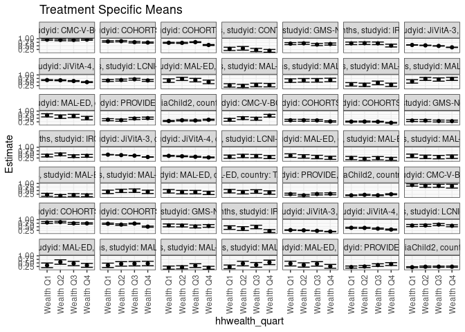

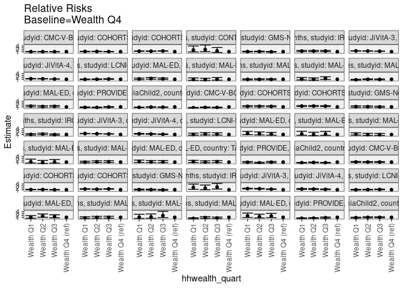

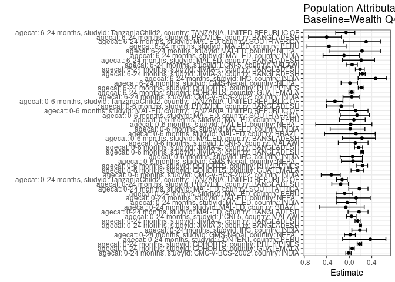

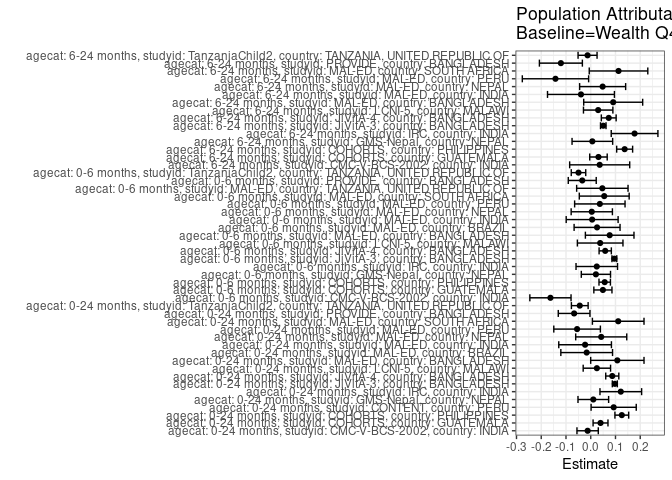

## Results Table

### Parameter: TSM

| agecat | studyid | country | intervention_level | baseline_level | estimate | ci_lower | ci_upper |
| --- | --- | --- | --- | --- | --- | --- | --- |
| 0-24 months | CMC-V-BCS-2002 | INDIA | Wealth Q4 | NA | 0.9375000 | 0.8890135 | 0.9859865 |
| 0-24 months | CMC-V-BCS-2002 | INDIA | Wealth Q1 | NA | 0.9340659 | 0.8830091 | 0.9851228 |
| 0-24 months | CMC-V-BCS-2002 | INDIA | Wealth Q2 | NA | 0.9157895 | 0.8598717 | 0.9717073 |
| 0-24 months | CMC-V-BCS-2002 | INDIA | Wealth Q3 | NA | 0.9120879 | 0.8538303 | 0.9703456 |
| 0-24 months | COHORTS | GUATEMALA | Wealth Q4 | NA | 0.7319588 | 0.6925229 | 0.7713946 |
| 0-24 months | COHORTS | GUATEMALA | Wealth Q1 | NA | 0.8081633 | 0.7588402 | 0.8574864 |
| 0-24 months | COHORTS | GUATEMALA | Wealth Q2 | NA | 0.8269231 | 0.7809204 | 0.8729258 |
| 0-24 months | COHORTS | GUATEMALA | Wealth Q3 | NA | 0.7569444 | 0.7073873 | 0.8065016 |
| 0-24 months | COHORTS | PHILIPPINES | Wealth Q4 | NA | 0.5610913 | 0.5275864 | 0.5945963 |
| 0-24 months | COHORTS | PHILIPPINES | Wealth Q1 | NA | 0.7161572 | 0.6824375 | 0.7498769 |
| 0-24 months | COHORTS | PHILIPPINES | Wealth Q2 | NA | 0.7103321 | 0.6721376 | 0.7485266 |
| 0-24 months | COHORTS | PHILIPPINES | Wealth Q3 | NA | 0.7604061 | 0.7337460 | 0.7870662 |
| 0-24 months | CONTENT | PERU | Wealth Q4 | NA | 0.1538462 | 0.0555522 | 0.2521401 |
| 0-24 months | CONTENT | PERU | Wealth Q1 | NA | 0.2881356 | 0.1723028 | 0.4039684 |
| 0-24 months | CONTENT | PERU | Wealth Q2 | NA | 0.3269231 | 0.1991281 | 0.4547181 |
| 0-24 months | CONTENT | PERU | Wealth Q3 | NA | 0.2115385 | 0.1002773 | 0.3227996 |
| 0-24 months | GMS-Nepal | NEPAL | Wealth Q4 | NA | 0.6285714 | 0.5569315 | 0.7002114 |
| 0-24 months | GMS-Nepal | NEPAL | Wealth Q1 | NA | 0.6571429 | 0.5867665 | 0.7275192 |
| 0-24 months | GMS-Nepal | NEPAL | Wealth Q2 | NA | 0.6781609 | 0.6086952 | 0.7476266 |
| 0-24 months | GMS-Nepal | NEPAL | Wealth Q3 | NA | 0.5919540 | 0.5188766 | 0.6650315 |
| 0-24 months | IRC | INDIA | Wealth Q4 | NA | 0.5200000 | 0.4219606 | 0.6180394 |
| 0-24 months | IRC | INDIA | Wealth Q1 | NA | 0.6761905 | 0.5865791 | 0.7658018 |
| 0-24 months | IRC | INDIA | Wealth Q2 | NA | 0.6862745 | 0.5961170 | 0.7764321 |
| 0-24 months | IRC | INDIA | Wealth Q3 | NA | 0.6796117 | 0.5893863 | 0.7698370 |
| 0-24 months | JiVitA-3 | BANGLADESH | Wealth Q4 | NA | 0.3980718 | 0.3853698 | 0.4107738 |
| 0-24 months | JiVitA-3 | BANGLADESH | Wealth Q1 | NA | 0.5614941 | 0.5483329 | 0.5746553 |
| 0-24 months | JiVitA-3 | BANGLADESH | Wealth Q2 | NA | 0.5346281 | 0.5220995 | 0.5471568 |
| 0-24 months | JiVitA-3 | BANGLADESH | Wealth Q3 | NA | 0.4955999 | 0.4825576 | 0.5086421 |
| 0-24 months | JiVitA-4 | BANGLADESH | Wealth Q4 | NA | 0.4948148 | 0.4632425 | 0.5263871 |
| 0-24 months | JiVitA-4 | BANGLADESH | Wealth Q1 | NA | 0.6370262 | 0.6062836 | 0.6677689 |

[output cut: 166 more lines]

### Parameter: E(Y)

| agecat | studyid | country | intervention_level | baseline_level | estimate | ci_lower | ci_upper |
| --- | --- | --- | --- | --- | --- | --- | --- |
| 0-24 months | CMC-V-BCS-2002 | INDIA | NA | NA | 0.9249330 | 0.8981563 | 0.9517096 |
| 0-24 months | COHORTS | GUATEMALA | NA | NA | 0.7715180 | 0.7484902 | 0.7945458 |
| 0-24 months | COHORTS | PHILIPPINES | NA | NA | 0.6866209 | 0.6701747 | 0.7030670 |
| 0-24 months | CONTENT | PERU | NA | NA | 0.2465116 | 0.1887688 | 0.3042545 |
| 0-24 months | GMS-Nepal | NEPAL | NA | NA | 0.6389685 | 0.6033115 | 0.6746254 |
| 0-24 months | IRC | INDIA | NA | NA | 0.6414634 | 0.5949863 | 0.6879405 |
| 0-24 months | JiVitA-3 | BANGLADESH | NA | NA | 0.4954233 | 0.4875870 | 0.5032596 |
| 0-24 months | JiVitA-4 | BANGLADESH | NA | NA | 0.5818282 | 0.5658219 | 0.5978346 |
| 0-24 months | LCNI-5 | MALAWI | NA | NA | 0.6376989 | 0.6047193 | 0.6706785 |
| 0-24 months | MAL-ED | BANGLADESH | NA | NA | 0.6157025 | 0.5542897 | 0.6771153 |
| 0-24 months | MAL-ED | BRAZIL | NA | NA | 0.2666667 | 0.2067138 | 0.3266195 |
| 0-24 months | MAL-ED | INDIA | NA | NA | 0.6212766 | 0.5591262 | 0.6834270 |
| 0-24 months | MAL-ED | NEPAL | NA | NA | 0.3474576 | 0.2865784 | 0.4083369 |
| 0-24 months | MAL-ED | PERU | NA | NA | 0.6654412 | 0.6092647 | 0.7216177 |
| 0-24 months | MAL-ED | SOUTH AFRICA | NA | NA | 0.6186770 | 0.5591785 | 0.6781756 |
| 0-24 months | PROVIDE | BANGLADESH | NA | NA | 0.4357143 | 0.3989556 | 0.4724730 |
| 0-24 months | TanzaniaChild2 | TANZANIA, UNITED REPUBLIC OF | NA | NA | 0.3468960 | 0.3277853 | 0.3660067 |
| 0-6 months | CMC-V-BCS-2002 | INDIA | NA | NA | 0.5108696 | 0.4597270 | 0.5620121 |
| 0-6 months | COHORTS | GUATEMALA | NA | NA | 0.3240116 | 0.2955133 | 0.3525098 |
| 0-6 months | COHORTS | PHILIPPINES | NA | NA | 0.2391233 | 0.2240003 | 0.2542464 |
| 0-6 months | GMS-Nepal | NEPAL | NA | NA | 0.3180516 | 0.2834770 | 0.3526261 |
| 0-6 months | IRC | INDIA | NA | NA | 0.4243902 | 0.3764905 | 0.4722900 |
| 0-6 months | JiVitA-3 | BANGLADESH | NA | NA | 0.4130891 | 0.4056400 | 0.4205383 |
| 0-6 months | JiVitA-4 | BANGLADESH | NA | NA | 0.3474692 | 0.3322601 | 0.3626783 |
| 0-6 months | LCNI-5 | MALAWI | NA | NA | 0.3531599 | 0.2959376 | 0.4103821 |
| 0-6 months | MAL-ED | BANGLADESH | NA | NA | 0.3388430 | 0.2790857 | 0.3986003 |
| 0-6 months | MAL-ED | BRAZIL | NA | NA | 0.2142857 | 0.1586564 | 0.2699151 |
| 0-6 months | MAL-ED | INDIA | NA | NA | 0.3446809 | 0.2837868 | 0.4055749 |
| 0-6 months | MAL-ED | NEPAL | NA | NA | 0.1737288 | 0.1252880 | 0.2221696 |
| 0-6 months | MAL-ED | PERU | NA | NA | 0.4485294 | 0.3893160 | 0.5077428 |
| 0-6 months | MAL-ED | SOUTH AFRICA | NA | NA | 0.3929961 | 0.3331663 | 0.4528260 |
| 0-6 months | MAL-ED | TANZANIA, UNITED REPUBLIC OF | NA | NA | 0.4120000 | 0.3508656 | 0.4731344 |
| 0-6 months | PROVIDE | BANGLADESH | NA | NA | 0.2400000 | 0.2083392 | 0.2716608 |
| 0-6 months | TanzaniaChild2 | TANZANIA, UNITED REPUBLIC OF | NA | NA | 0.1950503 | 0.1791413 | 0.2109594 |
| 6-24 months | CMC-V-BCS-2002 | INDIA | NA | NA | 0.8486486 | 0.7968646 | 0.9004327 |
| 6-24 months | COHORTS | GUATEMALA | NA | NA | 0.7665094 | 0.7380190 | 0.7949999 |
| 6-24 months | COHORTS | PHILIPPINES | NA | NA | 0.6449788 | 0.6246093 | 0.6653483 |
| 6-24 months | GMS-Nepal | NEPAL | NA | NA | 0.5642317 | 0.5153938 | 0.6130696 |
| 6-24 months | IRC | INDIA | NA | NA | 0.3771186 | 0.3151523 | 0.4390850 |
| 6-24 months | JiVitA-3 | BANGLADESH | NA | NA | 0.2161518 | 0.2067762 | 0.2255274 |
| 6-24 months | JiVitA-4 | BANGLADESH | NA | NA | 0.3784303 | 0.3598372 | 0.3970234 |
| 6-24 months | LCNI-5 | MALAWI | NA | NA | 0.6000000 | 0.5639396 | 0.6360604 |
| 6-24 months | MAL-ED | BANGLADESH | NA | NA | 0.4240506 | 0.3467471 | 0.5013542 |
| 6-24 months | MAL-ED | INDIA | NA | NA | 0.4220779 | 0.3438191 | 0.5003367 |
| 6-24 months | MAL-ED | NEPAL | NA | NA | 0.2113402 | 0.1537425 | 0.2689379 |
| 6-24 months | MAL-ED | PERU | NA | NA | 0.3959732 | 0.3171819 | 0.4747644 |
| 6-24 months | MAL-ED | SOUTH AFRICA | NA | NA | 0.3741935 | 0.2977649 | 0.4506221 |
| 6-24 months | PROVIDE | BANGLADESH | NA | NA | 0.3004386 | 0.2583143 | 0.3425629 |
| 6-24 months | TanzaniaChild2 | TANZANIA, UNITED REPUBLIC OF | NA | NA | 0.2268170 | 0.2062654 | 0.2473687 |

### Parameter: RR

| agecat | studyid | country | intervention_level | baseline_level | estimate | ci_lower | ci_upper |
| --- | --- | --- | --- | --- | --- | --- | --- |
| 0-24 months | CMC-V-BCS-2002 | INDIA | Wealth Q4 | Wealth Q4 | 1.0000000 | 1.0000000 | 1.0000000 |
| 0-24 months | CMC-V-BCS-2002 | INDIA | Wealth Q1 | Wealth Q4 | 0.9963370 | 0.9241135 | 1.0742051 |
| 0-24 months | CMC-V-BCS-2002 | INDIA | Wealth Q2 | Wealth Q4 | 0.9768421 | 0.9017212 | 1.0582212 |
| 0-24 months | CMC-V-BCS-2002 | INDIA | Wealth Q3 | Wealth Q4 | 0.9728938 | 0.8961328 | 1.0562300 |
| 0-24 months | COHORTS | GUATEMALA | Wealth Q4 | Wealth Q4 | 1.0000000 | 1.0000000 | 1.0000000 |
| 0-24 months | COHORTS | GUATEMALA | Wealth Q1 | Wealth Q4 | 1.1041104 | 1.0177865 | 1.1977558 |
| 0-24 months | COHORTS | GUATEMALA | Wealth Q2 | Wealth Q4 | 1.1297400 | 1.0455504 | 1.2207086 |
| 0-24 months | COHORTS | GUATEMALA | Wealth Q3 | Wealth Q4 | 1.0341354 | 0.9500670 | 1.1256426 |
| 0-24 months | COHORTS | PHILIPPINES | Wealth Q4 | Wealth Q4 | 1.0000000 | 1.0000000 | 1.0000000 |
| 0-24 months | COHORTS | PHILIPPINES | Wealth Q1 | Wealth Q4 | 1.2763647 | 1.1829036 | 1.3772103 |
| 0-24 months | COHORTS | PHILIPPINES | Wealth Q2 | Wealth Q4 | 1.2659830 | 1.1682346 | 1.3719102 |
| 0-24 months | COHORTS | PHILIPPINES | Wealth Q3 | Wealth Q4 | 1.3552269 | 1.2645586 | 1.4523962 |
| 0-24 months | CONTENT | PERU | Wealth Q4 | Wealth Q4 | 1.0000000 | 1.0000000 | 1.0000000 |
| 0-24 months | CONTENT | PERU | Wealth Q1 | Wealth Q4 | 1.8728814 | 0.8803953 | 3.9842154 |
| 0-24 months | CONTENT | PERU | Wealth Q2 | Wealth Q4 | 2.1250000 | 1.0047762 | 4.4941600 |
| 0-24 months | CONTENT | PERU | Wealth Q3 | Wealth Q4 | 1.3750000 | 0.6010371 | 3.1456043 |
| 0-24 months | GMS-Nepal | NEPAL | Wealth Q4 | Wealth Q4 | 1.0000000 | 1.0000000 | 1.0000000 |
| 0-24 months | GMS-Nepal | NEPAL | Wealth Q1 | Wealth Q4 | 1.0454545 | 0.8940961 | 1.2224359 |
| 0-24 months | GMS-Nepal | NEPAL | Wealth Q2 | Wealth Q4 | 1.0788924 | 0.9256084 | 1.2575607 |
| 0-24 months | GMS-Nepal | NEPAL | Wealth Q3 | Wealth Q4 | 0.9417450 | 0.7960936 | 1.1140445 |
| 0-24 months | IRC | INDIA | Wealth Q4 | Wealth Q4 | 1.0000000 | 1.0000000 | 1.0000000 |
| 0-24 months | IRC | INDIA | Wealth Q1 | Wealth Q4 | 1.3003663 | 1.0327161 | 1.6373837 |
| 0-24 months | IRC | INDIA | Wealth Q2 | Wealth Q4 | 1.3197587 | 1.0488092 | 1.6607052 |
| 0-24 months | IRC | INDIA | Wealth Q3 | Wealth Q4 | 1.3069455 | 1.0378000 | 1.6458918 |
| 0-24 months | JiVitA-3 | BANGLADESH | Wealth Q4 | Wealth Q4 | 1.0000000 | 1.0000000 | 1.0000000 |
| 0-24 months | JiVitA-3 | BANGLADESH | Wealth Q1 | Wealth Q4 | 1.4105346 | 1.3576993 | 1.4654260 |
| 0-24 months | JiVitA-3 | BANGLADESH | Wealth Q2 | Wealth Q4 | 1.3430444 | 1.2954034 | 1.3924374 |
| 0-24 months | JiVitA-3 | BANGLADESH | Wealth Q3 | Wealth Q4 | 1.2450012 | 1.1972931 | 1.2946103 |
| 0-24 months | JiVitA-4 | BANGLADESH | Wealth Q4 | Wealth Q4 | 1.0000000 | 1.0000000 | 1.0000000 |
| 0-24 months | JiVitA-4 | BANGLADESH | Wealth Q1 | Wealth Q4 | 1.2874033 | 1.1909720 | 1.3916426 |

[output cut: 166 more lines]

### Parameter: PAR

| agecat | studyid | country | intervention_level | baseline_level | estimate | ci_lower | ci_upper |
| --- | --- | --- | --- | --- | --- | --- | --- |
| 0-24 months | CMC-V-BCS-2002 | INDIA | Wealth Q4 | NA | -0.0125670 | -0.0556692 | 0.0305351 |
| 0-24 months | COHORTS | GUATEMALA | Wealth Q4 | NA | 0.0395592 | 0.0094747 | 0.0696438 |
| 0-24 months | COHORTS | PHILIPPINES | Wealth Q4 | NA | 0.1255295 | 0.0977099 | 0.1533492 |
| 0-24 months | CONTENT | PERU | Wealth Q4 | NA | 0.0926655 | 0.0014385 | 0.1838925 |
| 0-24 months | GMS-Nepal | NEPAL | Wealth Q4 | NA | 0.0103971 | -0.0514916 | 0.0722857 |
| 0-24 months | IRC | INDIA | Wealth Q4 | NA | 0.1214634 | 0.0373017 | 0.2056252 |
| 0-24 months | JiVitA-3 | BANGLADESH | Wealth Q4 | NA | 0.0973515 | 0.0872458 | 0.1074572 |
| 0-24 months | JiVitA-4 | BANGLADESH | Wealth Q4 | NA | 0.0870134 | 0.0606066 | 0.1134203 |
| 0-24 months | LCNI-5 | MALAWI | Wealth Q4 | NA | 0.0247957 | -0.0305123 | 0.0801037 |
| 0-24 months | MAL-ED | BANGLADESH | Wealth Q4 | NA | 0.1075058 | -0.0002375 | 0.2152490 |
| 0-24 months | MAL-ED | BRAZIL | Wealth Q4 | NA | -0.0163522 | -0.1208175 | 0.0881131 |
| 0-24 months | MAL-ED | INDIA | Wealth Q4 | NA | -0.0227912 | -0.1292133 | 0.0836309 |
| 0-24 months | MAL-ED | NEPAL | Wealth Q4 | NA | 0.0423729 | -0.0607655 | 0.1455112 |
| 0-24 months | MAL-ED | PERU | Wealth Q4 | NA | -0.0551471 | -0.1492951 | 0.0390010 |
| 0-24 months | MAL-ED | SOUTH AFRICA | Wealth Q4 | NA | 0.1109847 | 0.0067348 | 0.2152347 |
| 0-24 months | PROVIDE | BANGLADESH | Wealth Q4 | NA | -0.0671429 | -0.1311658 | -0.0031199 |
| 0-24 months | TanzaniaChild2 | TANZANIA, UNITED REPUBLIC OF | Wealth Q4 | NA | -0.0443351 | -0.0781117 | -0.0105584 |
| 0-6 months | CMC-V-BCS-2002 | INDIA | Wealth Q4 | NA | -0.1628146 | -0.2460432 | -0.0795861 |
| 0-6 months | COHORTS | GUATEMALA | Wealth Q4 | NA | 0.0491425 | 0.0125320 | 0.0857529 |
| 0-6 months | COHORTS | PHILIPPINES | Wealth Q4 | NA | 0.0564424 | 0.0333352 | 0.0795497 |
| 0-6 months | GMS-Nepal | NEPAL | Wealth Q4 | NA | 0.0209087 | -0.0381197 | 0.0799371 |
| 0-6 months | IRC | INDIA | Wealth Q4 | NA | 0.0243902 | -0.0594436 | 0.1082241 |
| 0-6 months | JiVitA-3 | BANGLADESH | Wealth Q4 | NA | 0.0954619 | 0.0857043 | 0.1052195 |
| 0-6 months | JiVitA-4 | BANGLADESH | Wealth Q4 | NA | 0.0585107 | 0.0337442 | 0.0832772 |
| 0-6 months | LCNI-5 | MALAWI | Wealth Q4 | NA | 0.0380914 | -0.0540297 | 0.1302124 |
| 0-6 months | MAL-ED | BANGLADESH | Wealth Q4 | NA | 0.0765479 | -0.0216272 | 0.1747230 |
| 0-6 months | MAL-ED | BRAZIL | Wealth Q4 | NA | 0.0256065 | -0.0672143 | 0.1184273 |
| 0-6 months | MAL-ED | INDIA | Wealth Q4 | NA | 0.0056978 | -0.0991962 | 0.1105918 |
| 0-6 months | MAL-ED | NEPAL | Wealth Q4 | NA | 0.0042373 | -0.0791207 | 0.0875953 |
| 0-6 months | MAL-ED | PERU | Wealth Q4 | NA | 0.0367647 | -0.0650836 | 0.1386130 |
| 0-6 months | MAL-ED | SOUTH AFRICA | Wealth Q4 | NA | 0.0545346 | -0.0461841 | 0.1552533 |
| 0-6 months | MAL-ED | TANZANIA, UNITED REPUBLIC OF | Wealth Q4 | NA | 0.0469206 | -0.0568868 | 0.1507281 |
| 0-6 months | PROVIDE | BANGLADESH | Wealth Q4 | NA | -0.0342857 | -0.0907681 | 0.0221967 |
| 0-6 months | TanzaniaChild2 | TANZANIA, UNITED REPUBLIC OF | Wealth Q4 | NA | -0.0494691 | -0.0787043 | -0.0202338 |
| 6-24 months | CMC-V-BCS-2002 | INDIA | Wealth Q4 | NA | 0.0361486 | -0.0851282 | 0.1574255 |
| 6-24 months | COHORTS | GUATEMALA | Wealth Q4 | NA | 0.0312153 | -0.0041102 | 0.0665408 |
| 6-24 months | COHORTS | PHILIPPINES | Wealth Q4 | NA | 0.1370170 | 0.1047879 | 0.1692461 |
| 6-24 months | GMS-Nepal | NEPAL | Wealth Q4 | NA | 0.0065394 | -0.0755199 | 0.0885988 |
| 6-24 months | IRC | INDIA | Wealth Q4 | NA | 0.1771186 | 0.0827980 | 0.2714393 |
| 6-24 months | JiVitA-3 | BANGLADESH | Wealth Q4 | NA | 0.0506189 | 0.0395023 | 0.0617355 |
| 6-24 months | JiVitA-4 | BANGLADESH | Wealth Q4 | NA | 0.0727043 | 0.0427786 | 0.1026301 |
| 6-24 months | LCNI-5 | MALAWI | Wealth Q4 | NA | 0.0300518 | -0.0293602 | 0.0894638 |
| 6-24 months | MAL-ED | BANGLADESH | Wealth Q4 | NA | 0.0907173 | -0.0284138 | 0.2098484 |
| 6-24 months | MAL-ED | INDIA | Wealth Q4 | NA | -0.0394605 | -0.1746787 | 0.0957577 |
| 6-24 months | MAL-ED | NEPAL | Wealth Q4 | NA | 0.0480749 | -0.0449018 | 0.1410516 |
| 6-24 months | MAL-ED | PERU | Wealth Q4 | NA | -0.1424884 | -0.2764712 | -0.0085056 |
| 6-24 months | MAL-ED | SOUTH AFRICA | Wealth Q4 | NA | 0.1122888 | -0.0060027 | 0.2305803 |
| 6-24 months | PROVIDE | BANGLADESH | Wealth Q4 | NA | -0.1206140 | -0.2074303 | -0.0337978 |
| 6-24 months | TanzaniaChild2 | TANZANIA, UNITED REPUBLIC OF | Wealth Q4 | NA | -0.0128524 | -0.0512483 | 0.0255435 |

### Parameter: PAF

| agecat | studyid | country | intervention_level | baseline_level | estimate | ci_lower | ci_upper |
| --- | --- | --- | --- | --- | --- | --- | --- |
| 0-24 months | CMC-V-BCS-2002 | INDIA | Wealth Q4 | NA | -0.0135870 | -0.0613168 | 0.0319963 |
| 0-24 months | COHORTS | GUATEMALA | Wealth Q4 | NA | 0.0512745 | 0.0112993 | 0.0896335 |
| 0-24 months | COHORTS | PHILIPPINES | Wealth Q4 | NA | 0.1828222 | 0.1406470 | 0.2229275 |
| 0-24 months | CONTENT | PERU | Wealth Q4 | NA | 0.3759071 | -0.1179586 | 0.6516043 |
| 0-24 months | GMS-Nepal | NEPAL | Wealth Q4 | NA | 0.0162716 | -0.0855258 | 0.1085228 |
| 0-24 months | IRC | INDIA | Wealth Q4 | NA | 0.1893536 | 0.0453406 | 0.3116419 |
| 0-24 months | JiVitA-3 | BANGLADESH | Wealth Q4 | NA | 0.1965016 | 0.1756445 | 0.2168310 |
| 0-24 months | JiVitA-4 | BANGLADESH | Wealth Q4 | NA | 0.1495517 | 0.1025157 | 0.1941227 |
| 0-24 months | LCNI-5 | MALAWI | Wealth Q4 | NA | 0.0388830 | -0.0519420 | 0.1218662 |
| 0-24 months | MAL-ED | BANGLADESH | Wealth Q4 | NA | 0.1746067 | -0.0220758 | 0.3334407 |
| 0-24 months | MAL-ED | BRAZIL | Wealth Q4 | NA | -0.0613208 | -0.5350647 | 0.2662187 |
| 0-24 months | MAL-ED | INDIA | Wealth Q4 | NA | -0.0366845 | -0.2230564 | 0.1212877 |
| 0-24 months | MAL-ED | NEPAL | Wealth Q4 | NA | 0.1219512 | -0.2311573 | 0.3737846 |
| 0-24 months | MAL-ED | PERU | Wealth Q4 | NA | -0.0828729 | -0.2346646 | 0.0502573 |
| 0-24 months | MAL-ED | SOUTH AFRICA | Wealth Q4 | NA | 0.1793904 | -0.0094593 | 0.3329101 |
| 0-24 months | PROVIDE | BANGLADESH | Wealth Q4 | NA | -0.1540984 | -0.3113104 | -0.0157343 |
| 0-24 months | TanzaniaChild2 | TANZANIA, UNITED REPUBLIC OF | Wealth Q4 | NA | -0.1278050 | -0.2295548 | -0.0344754 |
| 0-6 months | CMC-V-BCS-2002 | INDIA | Wealth Q4 | NA | -0.3187010 | -0.4982213 | -0.1606912 |
| 0-6 months | COHORTS | GUATEMALA | Wealth Q4 | NA | 0.1516688 | 0.0309755 | 0.2573297 |
| 0-6 months | COHORTS | PHILIPPINES | Wealth Q4 | NA | 0.2360390 | 0.1337103 | 0.3262803 |
| 0-6 months | GMS-Nepal | NEPAL | Wealth Q4 | NA | 0.0657400 | -0.1395504 | 0.2340473 |
| 0-6 months | IRC | INDIA | Wealth Q4 | NA | 0.0574713 | -0.1623453 | 0.2357173 |
| 0-6 months | JiVitA-3 | BANGLADESH | Wealth Q4 | NA | 0.2310927 | 0.2069895 | 0.2544633 |
| 0-6 months | JiVitA-4 | BANGLADESH | Wealth Q4 | NA | 0.1683911 | 0.0936720 | 0.2369503 |
| 0-6 months | LCNI-5 | MALAWI | Wealth Q4 | NA | 0.1078587 | -0.1951078 | 0.3340215 |
| 0-6 months | MAL-ED | BANGLADESH | Wealth Q4 | NA | 0.2259096 | -0.1246751 | 0.4672098 |
| 0-6 months | MAL-ED | BRAZIL | Wealth Q4 | NA | 0.1194969 | -0.4391209 | 0.4612782 |
| 0-6 months | MAL-ED | INDIA | Wealth Q4 | NA | 0.0165307 | -0.3401331 | 0.2782717 |
| 0-6 months | MAL-ED | NEPAL | Wealth Q4 | NA | 0.0243902 | -0.5953455 | 0.4033804 |
| 0-6 months | MAL-ED | PERU | Wealth Q4 | NA | 0.0819672 | -0.1758157 | 0.2832345 |
| 0-6 months | MAL-ED | SOUTH AFRICA | Wealth Q4 | NA | 0.1387662 | -0.1598667 | 0.3605096 |
| 0-6 months | MAL-ED | TANZANIA, UNITED REPUBLIC OF | Wealth Q4 | NA | 0.1138850 | -0.1777292 | 0.3332935 |
| 0-6 months | PROVIDE | BANGLADESH | Wealth Q4 | NA | -0.1428571 | -0.4039265 | 0.0696646 |
| 0-6 months | TanzaniaChild2 | TANZANIA, UNITED REPUBLIC OF | Wealth Q4 | NA | -0.2536220 | -0.4122038 | -0.1128480 |
| 6-24 months | CMC-V-BCS-2002 | INDIA | Wealth Q4 | NA | 0.0425955 | -0.1117937 | 0.1755455 |
| 6-24 months | COHORTS | GUATEMALA | Wealth Q4 | NA | 0.0407240 | -0.0066252 | 0.0858460 |
| 6-24 months | COHORTS | PHILIPPINES | Wealth Q4 | NA | 0.2124364 | 0.1599614 | 0.2616335 |
| 6-24 months | GMS-Nepal | NEPAL | Wealth Q4 | NA | 0.0115900 | -0.1450962 | 0.1468364 |
| 6-24 months | IRC | INDIA | Wealth Q4 | NA | 0.4696629 | 0.1569609 | 0.6663768 |
| 6-24 months | JiVitA-3 | BANGLADESH | Wealth Q4 | NA | 0.2341822 | 0.1819395 | 0.2830887 |
| 6-24 months | JiVitA-4 | BANGLADESH | Wealth Q4 | NA | 0.1921208 | 0.1084681 | 0.2679244 |
| 6-24 months | LCNI-5 | MALAWI | Wealth Q4 | NA | 0.0500864 | -0.0543726 | 0.1441963 |
| 6-24 months | MAL-ED | BANGLADESH | Wealth Q4 | NA | 0.2139303 | -0.1243728 | 0.4504443 |
| 6-24 months | MAL-ED | INDIA | Wealth Q4 | NA | -0.0934911 | -0.4660977 | 0.1844180 |
| 6-24 months | MAL-ED | NEPAL | Wealth Q4 | NA | 0.2274764 | -0.3607913 | 0.5614369 |
| 6-24 months | MAL-ED | PERU | Wealth Q4 | NA | -0.3598435 | -0.7515813 | -0.0557172 |
| 6-24 months | MAL-ED | SOUTH AFRICA | Wealth Q4 | NA | 0.3000821 | -0.0979892 | 0.5538344 |
| 6-24 months | PROVIDE | BANGLADESH | Wealth Q4 | NA | -0.4014599 | -0.7237438 | -0.1394325 |
| 6-24 months | TanzaniaChild2 | TANZANIA, UNITED REPUBLIC OF | Wealth Q4 | NA | -0.0566641 | -0.2402244 | 0.0997283 |